# Medellins monthly predictive modelling per accident class

Alejandro Cadavid Romero

Universidad Nacional de Colombia  
alcadavidro@unal.edu.co

Santiago Vasquez Rodriguez

Universidad Nacional de Colombia  
svasquezro@unal.edu.co

# Introducción

Este documento hace parte del trabajo del curso de **Analítica Predictiva** de la Universidad Nacional de Colombia para la Maestría en Ingeniería y Especialización en Analítica. El alcance de este es la creación de modelos predictivos para la estimación de cantidad de accidentes en el valle del aburra a nivel mensual, semanal y diario.

### Carga de librerias

```r
# Manipulación de datos
library(dplyr)
library(tidyr)
library(lubridate)
# Data modelling
library(recipes)
library(Metrics)
library(glmnet)
library(caret)
library(MASS)
```

```r
# Visualización
library(ggplot2)

# Formato tablas
library(kableExtra)
```

### Carga de datos

```r
df_train <- read.csv('../../data/processed/train_data.csv')
df_test <- read.csv('../../data/processed/test_data.csv')
special_dates_train <- read.csv('../../data/processed/special_date_monthly_2017.csv')
special_dates_test <- read.csv('../../data/processed/special_date_monthly_2018.csv')
```

```r
kable(head(df_train)) %>%
  kable_styling(bootstrap_options = "striped", full_width = F) %>%
  scroll_box(width = "100%")
```

| X | DIA | PERIODO | CLASE | DIRECCION | DIRECCION_ENC | CBML | TIPO_GEOCOD | GRAVEDAD | BARRIO | COMUNA | DISENO | DIA_NOMBRE | MES | LONGITUD | LATITUD | FECHA |
| --- | --- | --- | --- | --- | --- | --- | --- | --- | --- | --- | --- | --- | --- | --- | --- | --- |
| 1 | 1 | 2014 | choque | cr 63 cl 94 | cr 063 094 000 00000 |  | no ubicada | solo danos |  |  | tramo de via | miercoles | 1 | -75.70382 | 6.221806 | 2014-01-01 19:00:00 |
| 2 | 1 | 2014 | choque | cl 30 cr 66 b | cl 030 066 b 000 00000 | 1602 | malla vial | solo danos | rosales | belen | interseccion | miercoles | 1 | -75.58727 | 6.231716 | 2014-01-01 07:40:00 |
| 3 | 1 | 2014 | choque | cr 52 cl 97 | cr 052 097 000 00000 | 0402 | malla vial | solo danos | san isidro | aranjuez | interseccion | miercoles | 1 | -75.56253 | 6.289907 | 2014-01-01 05:30:00 |
| 4 | 1 | 2014 | choque | tv 78 cl 65 | tv 078 065 000 00000 | 0519 | malla vial | solo danos | el progreso | castilla | tramo de via | miercoles | 1 | -75.57365 | 6.275473 | 2014-01-01 13:50:00 |
| 5 | 1 | 2014 | otro | cr 63 cl 50 | cr 063 050 000 00000 | 1101 | malla vial | solo danos | carlos e. restrepo | laureles estadio | tramo de via | miercoles | 1 | -75.57697 | 6.255457 | 2014-01-01 07:25:00 |
| 6 | 1 | 2014 | choque | cr 57 cl 51 | cr 057 051 000 00000 | 1006 | malla vial | solo danos | san benito | la candelaria | tramo de via | miercoles | 1 | -75.57481 | 6.254322 | 2014-01-01 04:15:00 |

# Armado del conjunto de datos

Debido a que se deben armar ciertas agregaciones a nivel de conjunto de datos antes de crear los datasets de entrenamiento, se incluye una etapa de armado del conjunto de variables, no está asociado directamente con la limpieza de los datos. La base que se construye a continuación serán los cimientos para el modelo mensual, el modelo semanal y el modelo diario.

```r
df <- rbind(
  df_train,
  df_test
)
special_dates_train <- special_dates_train %>%
  dplyr::select(PERIODO, MES, DIA, DIA_FESTIVO, FECHA_ESPECIAL, FESTIVO_FECHA_ESPECIAL)
special_dates_test <- special_dates_test %>%
  dplyr::select(PERIODO, MES, DIA, DIA_FESTIVO, FECHA_ESPECIAL, FESTIVO_FECHA_ESPECIAL)

special_dates <- rbind(
  special_dates_train,
  special_dates_test
)

df <- merge(df, special_dates, by = c("PERIODO", "MES", "DIA"))

kable(head(df)) %>%
  kable_styling(bootstrap_options = "striped", full_width = F) %>%
  scroll_box(width = "100%")
```

| PERIODO | MES | DIA | X | CLASE | DIRECCION | DIRECCION_ENC | CBML | TIPO_GEOCOD | GRAVEDAD | BARRIO | COMUNA | DISENO | DIA_NOMBRE | LONGITUD | LATITUD | FECHA | DIA_FESTIVO | FECHA_ESPECIAL | FESTIVO_FECHA_ESPECIAL |
| --- | --- | --- | --- | --- | --- | --- | --- | --- | --- | --- | --- | --- | --- | --- | --- | --- | --- | --- | --- |
| 2014 | 1 | 1 | 1 | choque | cr 63 cl 94 | cr 063 094 000 00000 |  | no ubicada | solo danos |  |  | tramo de via | miercoles | -75.70382 | 6.221806 | 2014-01-01 19:00:00 | 1 | 1 | 1 |
| 2014 | 1 | 1 | 2 | choque | cl 30 cr 66 b | cl 030 066 b 000 00000 | 1602 | malla vial | solo danos | rosales | belen | interseccion | miercoles | -75.58727 | 6.231716 | 2014-01-01 07:40:00 | 1 | 1 | 1 |
| 2014 | 1 | 1 | 3 | choque | cr 52 cl 97 | cr 052 097 000 00000 | 0402 | malla vial | solo danos | san isidro | aranjuez | interseccion | miercoles | -75.56253 | 6.289907 | 2014-01-01 05:30:00 | 1 | 1 | 1 |
| 2014 | 1 | 1 | 4 | choque | tv 78 cl 65 | tv 078 065 000 00000 | 0519 | malla vial | solo danos | el progreso | castilla | tramo de via | miercoles | -75.57365 | 6.275473 | 2014-01-01 13:50:00 | 1 | 1 | 1 |
| 2014 | 1 | 1 | 5 | otro | cr 63 cl 50 | cr 063 050 000 00000 | 1101 | malla vial | solo danos | carlos e. restrepo | laureles estadio | tramo de via | miercoles | -75.57697 | 6.255457 | 2014-01-01 07:25:00 | 1 | 1 | 1 |
| 2014 | 1 | 1 | 6 | choque | cr 57 cl 51 | cr 057 051 000 00000 | 1006 | malla vial | solo danos | san benito | la candelaria | tramo de via | miercoles | -75.57481 | 6.254322 | 2014-01-01 04:15:00 | 1 | 1 | 1 |

# Modelado mensual

## Clase choque

### Preprocesamiento de datos

```r
armado_dataset_mensual <- function(df, objective_var){
  # conjunto de datos mensual por clase
  accidentes_por_clase <- df %>%
    group_by(PERIODO, MES, CLASE) %>%
    summarise(n_accidentes=n(), .groups="drop") %>%
    spread(CLASE, n_accidentes) %>%
    mutate(PERIODO_LEAD=lead(PERIODO), MES_LEAD=lead(MES), rank = 1:length(PERIODO)) %>%
    filter(rank < max(rank)) %>%
    dplyr::select(-c(PERIODO, MES, rank))

  # conjunto de datos mensual por gravedad
  accidentes_por_gravedad <- df %>%
    group_by(PERIODO, MES, GRAVEDAD) %>%
    summarise(n_accidentes=n(), .groups="drop") %>%
    spread(GRAVEDAD, n_accidentes) %>%
    mutate(PERIODO_LEAD=lead(PERIODO), MES_LEAD=lead(MES), rank = 1:length(PERIODO)) %>%
    filter(rank < max(rank)) %>%
    dplyr::select(-c(PERIODO, MES, rank))

  # rezagos de la clase
  rezagos_accidentes <- df %>%
    filter(CLASE == objective_var) %>%
    group_by(PERIODO, MES) %>%
    summarise(n_accidentes=n(), .groups="drop") %>%
    mutate(
      FECHA=as.Date(paste(PERIODO, formatC(MES, width = 2, flag = "0"), "01", sep='-')),
      t_minus_1=lag(n_accidentes, n = 1),
      t_minus_2=lag(n_accidentes, n = 2)
    ) %>%
    dplyr::select(PERIODO, MES, t_minus_2)

  # Accidentes en los domingos
  domingos <- df %>%
    mutate(domingo = ifelse(DIA_NOMBRE == "domingo  ", 1, 0)) %>%
    group_by(PERIODO, MES) %>%
    summarise(accidentes_domingo=sum(domingo), .groups="drop") %>%
    mutate(PERIODO_LEAD=lead(PERIODO), MES_LEAD=lead(MES), rank = 1:length(PERIODO)) %>%
    filter(rank < max(rank)) %>%
    dplyr::select(-c(PERIODO, MES, rank))


  # fechas especiales
  fechas_meses <- special_dates %>%
    group_by(PERIODO, MES) %>%
    summarise(
      dias_festivos=sum(DIA_FESTIVO),
      dias_especiales=sum(FECHA_ESPECIAL),
      dias_festivos_especiales=sum(FESTIVO_FECHA_ESPECIAL),
      .groups="drop"
    )

  df_processed <- df %>%
    filter(CLASE == objective_var) %>%
    group_by(PERIODO, MES) %>%
    summarise(
      numero_accidentes = n(),
      .groups="drop"
    ) %>%
    mutate(
      MES=factor(MES)
      ) %>%
    merge(accidentes_por_clase,
          by.x = c("PERIODO", "MES"), by.y = c("PERIODO_LEAD", "MES_LEAD"), all.x = T) %>%
    replace_na(list(incendio=0)) %>%
    merge(accidentes_por_gravedad, by.x = c("PERIODO", "MES"), by.y = c("PERIODO_LEAD", "MES_LEAD"), all.x = T) %>%
    merge(rezagos_accidentes, by = c("PERIODO", "MES"), all.x = T) %>%
    merge(domingos, by.x = c("PERIODO", "MES"), by.y = c("PERIODO_LEAD", "MES_LEAD"), all.x = T) %>%
    filter(!is.na(t_minus_2)) %>%
    merge(fechas_meses, by = c("PERIODO", "MES")) %>%
    arrange(PERIODO, MES, .by_group = T)

  return(df_processed)
}

df_preprocessed <- armado_dataset_mensual(df=df, objective_var = "choque")
df_choque_train <- df_preprocessed %>% filter(PERIODO!=2018) %>% dplyr::select(-c(PERIODO))
df_choque_test <- df_preprocessed %>% filter(PERIODO==2018) %>% dplyr::select(-c(PERIODO))
```

### Modelado

Para el modelado de cada clase en el modelo mensual se intentarán sólo modelos lineales, ya que se cuentan con menos de 50 datos por clase de accidente, por lo que un modelo no-lineal como arboles de decisión o modelos más avanzados tenderían a sobreajustarse fácilmente. Primero, se procede a escalar los datos números a escala logarítmica para aproximarlos lo más posible a una normal.

```r
df_choque_train <- df_choque_train %>%
  mutate(
    incendio=incendio+1,
    dias_festivos=dias_festivos+1,
    dias_especiales=dias_especiales+1,
    dias_festivos_especiales=dias_festivos_especiales+1
    )

model.choque.recipe <- recipe(numero_accidentes ~ .,
                              data = df_choque_train)
model.choque.steps <- model.choque.recipe %>%
  step_log(all_outcomes()) %>%
  step_center(all_predictors(), -MES) %>%
  step_scale(all_predictors(), -MES)

model.choque.prepared <- prep(model.choque.steps, training = df_choque_train)
df_choque_train <- bake(model.choque.prepared, df_choque_train)

df_choque_test <- df_choque_test %>%
  mutate(
    incendio=incendio+1,
    dias_festivos=dias_festivos+1,
    dias_especiales=dias_especiales+1,
    dias_festivos_especiales=dias_festivos_especiales+1
    )
df_choque_test <- bake(model.choque.prepared, df_choque_test)
```

Se procede a realizar un ajuste de regresión lineal con un **stepwise elimination** para seleccionar variables.

```r
modelo.choque <- lm(numero_accidentes ~ ., data=df_choque_train)
step.model.choque <- stepAIC(modelo.choque, direction = "both", trace = F, steps = 2000)

model.choque.summary <- summary(step.model.choque)
model.choque.summary
```

```
##
## Call:
## lm(formula = numero_accidentes ~ MES + atropello + volcamiento +
##     t_minus_2 + accidentes_domingo + dias_festivos_especiales,
##     data = df_choque_train)
##
## Residuals:
##       Min        1Q    Median        3Q       Max
## -0.074476 -0.013454 -0.001352  0.010284  0.060137
##
## Coefficients:
##                           Estimate Std. Error t value Pr(>|t|)
## (Intercept)               7.736251   0.020209 382.813  < 2e-16 ***
## MES2                      0.079059   0.029441   2.685 0.011859 *
## MES3                      0.206976   0.030252   6.842 1.63e-07 ***
## MES4                      0.136121   0.024614   5.530 5.82e-06 ***
## MES5                      0.138698   0.025407   5.459 7.09e-06 ***
## MES6                      0.042803   0.027834   1.538 0.134945
## MES7                      0.156560   0.025760   6.078 1.29e-06 ***
## MES8                      0.209277   0.025946   8.066 6.79e-09 ***
## MES9                      0.143446   0.032209   4.454 0.000115 ***
## MES10                     0.142001   0.032048   4.431 0.000123 ***
## MES11                     0.034308   0.031670   1.083 0.287611
## MES12                     0.119634   0.026406   4.531 9.33e-05 ***
## atropello                -0.009722   0.007173  -1.355 0.185776
## volcamiento               0.010699   0.006407   1.670 0.105696
## t_minus_2                 0.027853   0.010731   2.596 0.014667 *
## accidentes_domingo        0.009678   0.005205   1.860 0.073115 .
## dias_festivos_especiales -0.020521   0.007807  -2.628 0.013574 *
## ---
## Signif. codes:  0 '***' 0.001 '**' 0.01 '*' 0.05 '.' 0.1 ' ' 1
##
## Residual standard error: 0.03072 on 29 degrees of freedom
## Multiple R-squared:  0.8853, Adjusted R-squared:  0.822
## F-statistic: 13.99 on 16 and 29 DF,  p-value: 1.478e-09
```

El modelo tiene un r2 de 0.8852856 lo cual es un buen indicativo, y un r2 ajustado de 0.8219948, lo cual refleja la penalidad que le está dando el modelo a un alto número de variables usadas. Sin embargo, el desempeño del modelo sigue estando por unos valores intersantes. A continuación se realiza el análisis de errores y de rendimiento con el **RMSE**.

**Evaluación en entrenamiento**

```r
plot_estimation_errors <- function(y_true, y_pred, title){
  min_value <- min(y_true, y_pred) - min(y_true, y_pred) * 0.1
  max_value <- max(y_true, y_pred) + max(y_true, y_pred) * 0.1

  plot(x=y_true,y=y_pred,
       ylab="Predicciones",xlab="Observados",
       xlim=c(min_value, max_value),ylim=c(min_value, max_value),
       las=1, cex=1, pch=16,
       main=title)
  abline(a=0,b=1,lwd=2,col="black", lty=2)
  R_vl<-cor(y_pred, y_true)
  R_vl<-format(R_vl, digits = 3, nsmall = 3)
  rmse_vl<- rmse(actual = y_true, predicted = y_pred)
  rmse_vl<-format(rmse_vl,digits = 3,nsmall = 2)
  grid()
  legend("topleft",legend=paste0(c("Correlación: ","RMSE: "),c(R_vl,rmse_vl)), bty="n")
}
```

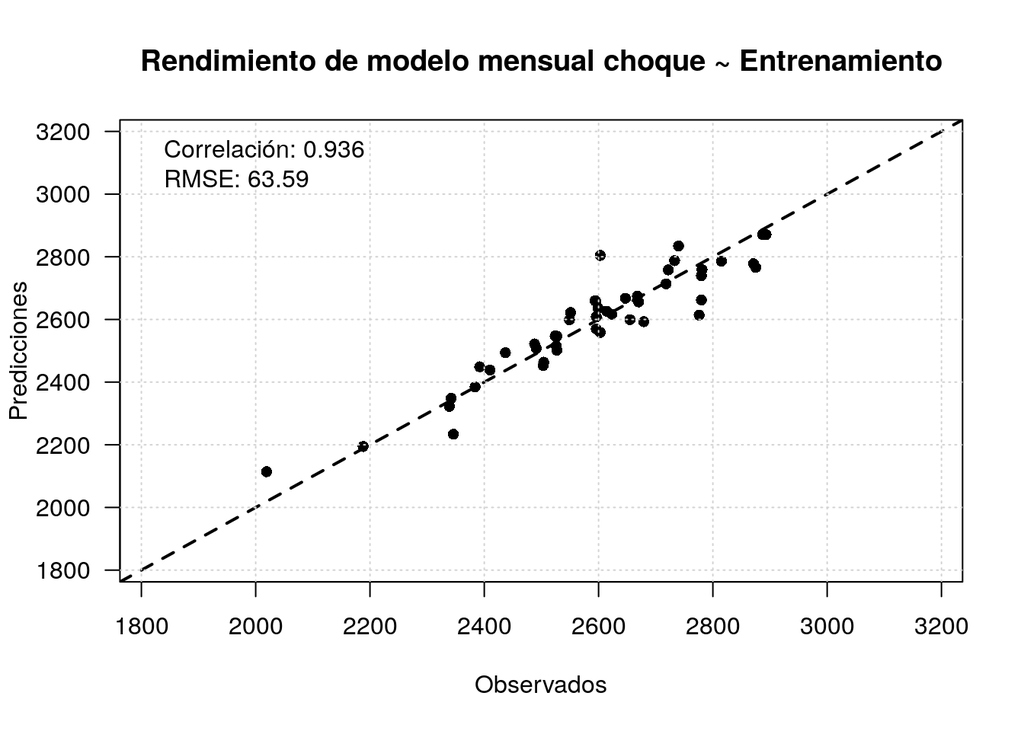

```r
y_pred <- exp(predict(step.model.choque, df_choque_train))
y_true <- exp(df_choque_train$numero_accidentes)

train_rmse <- rmse(y_true, y_pred)

plot_estimation_errors(
  y_true = y_true,
  y_pred = y_pred,
  title="Rendimiento de modelo mensual choque ~ Entrenamiento"
  )
```

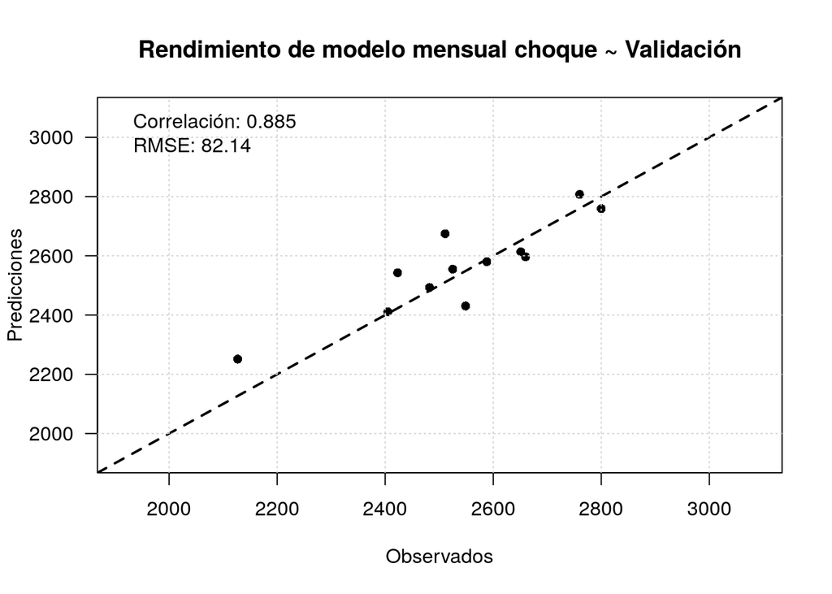

```r
y_pred <- exp(predict(step.model.choque, df_choque_test))
y_true <- exp(df_choque_test$numero_accidentes)

test_rmse <- rmse(y_true, y_pred)

test_train_ratio <- round(((test_rmse / train_rmse) - 1)*100, 3)

plot_estimation_errors(
  y_true = y_true,
  y_pred = y_pred,
  title="Rendimiento de modelo mensual choque ~ Validación"
  )
```

Si bien en el conjunto de validación se comprueba que el error sigue siendo bajo, hablando de manera subjetiva, al hacer un simple cálculo de variación respecto al error de entrenamiento es de un 29.181% lo cual es una señal de sobre-entrenenamiento, por lo que el método inicial de selección de variables no parece ser el más apropiado. Por lo tanto, se procede a evalua un modelo de regresión lineal con regularización lasso.

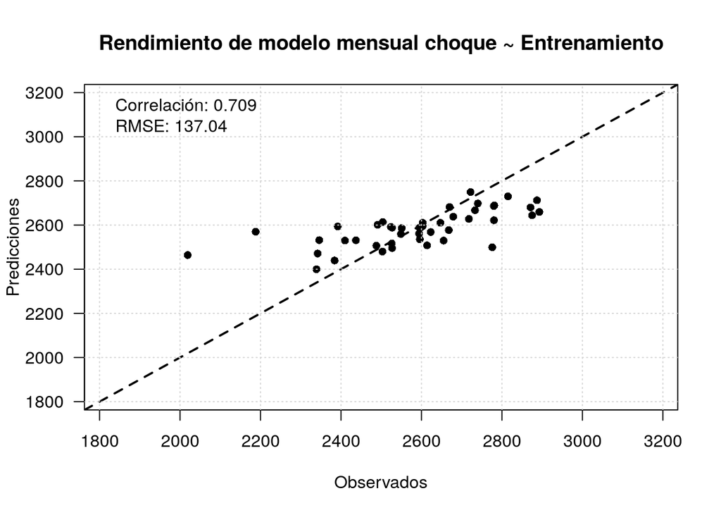

```r
# Construcción del dataset
x_train <- model.matrix(numero_accidentes~. , df_choque_train)[,-1]
y_train <- df_choque_train$numero_accidentes

# malla de lambdas a probar
lambda_seq <- 10^seq(2, -2, by = -.1)

# modelado
set.seed(42)
cv.lasso.choque <- cv.glmnet(x_train, y_train,
                             alpha = 1, lambda = lambda_seq,
                             nfolds = 5)

lasso.model.choque <- glmnet(x_train, y_train, alpha = 1, lambda = cv.lasso.choque$lambda.min)

y_pred <- predict(lasso.model.choque, x_train)

train_rmse <- rmse(exp(y_train), exp(y_pred))

plot_estimation_errors(
  y_true = exp(y_train),
  y_pred = exp(y_pred),
  title="Rendimiento de modelo mensual choque ~ Entrenamiento"
  )
```

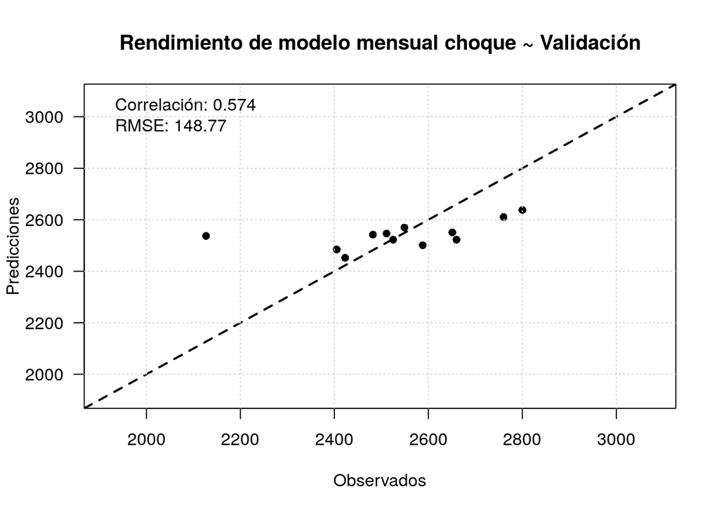

```r
x_test <- model.matrix(numero_accidentes~. , df_choque_test)[,-1]
y_test <- df_choque_test$numero_accidentes
y_pred <- predict(lasso.model.choque, x_test)

test_rmse <- rmse(exp(y_test), exp(y_pred))

plot_estimation_errors(
  y_true = exp(y_test),
  y_pred = exp(y_pred),
  title="Rendimiento de modelo mensual choque ~ Validación"
  )
```

```r
test_train_ratio <- round((test_rmse / train_rmse -1 )*100, 3)
```

Como se puede observar, con la regularización lasso, el modelo de choque mensual tiene unas predicciones más restrictivas ya que está penalizando fuertemente los regresores con altos coeficientes, sin embargo, la variación del error está alrededor del 8.557% lo cual es más aceptable dado que la anterior, estaba alrededor del 30%. Por ende, concluímos que el modelo usando penalización lasso es más apropiado al de la regresión lineal con selección stepwise.

## Atropello

```r
prepare_data <- function(df, objective_var){
  # Data preparation
  df_preprocessed <- armado_dataset_mensual(df=df, objective_var = objective_var)
  # Data splitting
  df_tmp_train <- df_preprocessed %>% filter(PERIODO!=2018) %>% dplyr::select(-c(PERIODO))
  df_tmp_test <- df_preprocessed %>% filter(PERIODO==2018) %>% dplyr::select(-c(PERIODO))

  # Data preprocess
  df_tmp_train <- df_tmp_train %>%
    mutate(
      incendio=incendio+1,
      dias_festivos=dias_festivos+1,
      dias_especiales=dias_especiales+1,
      dias_festivos_especiales=dias_festivos_especiales+1
    )
  # Data recipes
  model.tmp.recipe <- recipe(
    numero_accidentes ~ .,
    data = df_tmp_train
    )
  model.tmp.steps <- model.tmp.recipe %>%
    step_log(all_outcomes()) %>%
    step_center(all_predictors(), -MES) %>%
    step_scale(all_predictors(), -MES)

  model.tmp.prepared <- prep(model.tmp.steps, training = df_tmp_train)

  # Data pipeline
  df_tmp_train <- bake(model.tmp.prepared, df_tmp_train)

  # Applying pipeline to test set
  df_tmp_test <- df_tmp_test %>%
    mutate(
      incendio=incendio+1,
      dias_festivos=dias_festivos+1,
      dias_especiales=dias_especiales+1,
      dias_festivos_especiales=dias_festivos_especiales+1
    )
  df_tmp_test <- bake(model.tmp.prepared, df_tmp_test)

  response = list(
    "training"=df_tmp_train,
    "validation"=df_tmp_test,
    "model_recipe"=list(
      "recipe"=model.tmp.recipe,
      "steps"=model.tmp.steps,
      "prepared"=model.tmp.prepared
    )
  )
  return(response)
}

data.atropello <- prepare_data(df=df, objective_var = "atropello")
df_atropello_train <- data.atropello$training
df_atropello_test <- data.atropello$validation
```

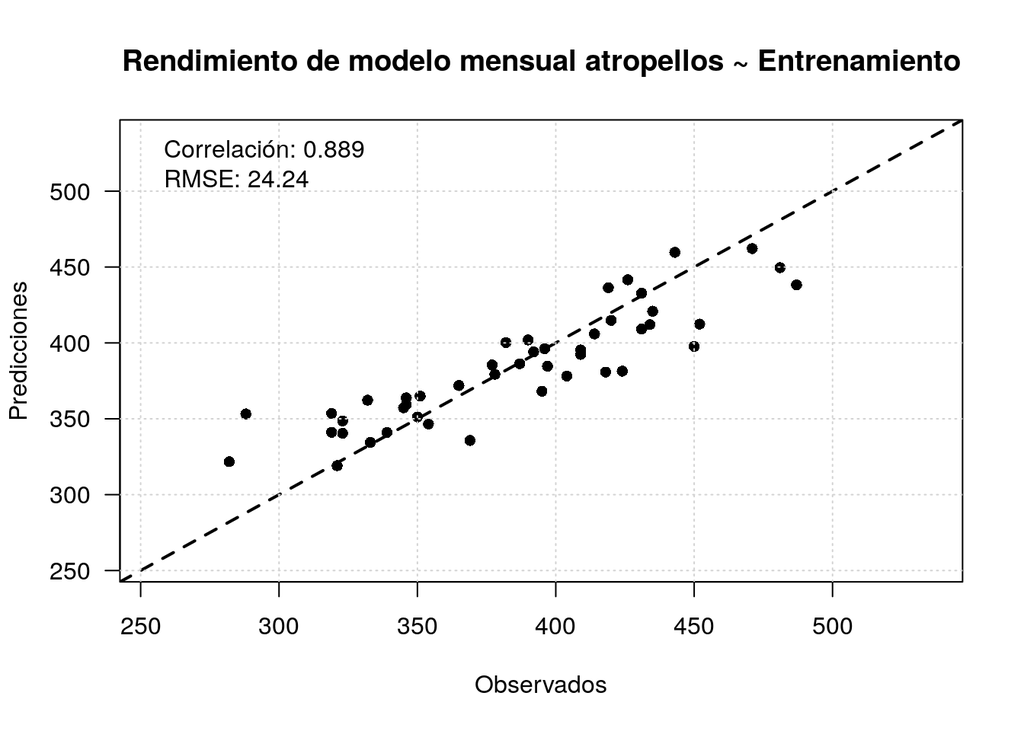

```r
train_lasso_model <- function(df_train, df_test, min_lambda=-2){
  # Construcción del dataset
  x_train <- model.matrix(numero_accidentes~. , df_train)[,-1]
  y_train <- df_train$numero_accidentes

  # malla de lambdas a probar
  lambda_seq <- 10^seq(2, min_lambda, by = -.1)

  # modelado
  set.seed(42)
  cv.lasso <- cv.glmnet(x_train, y_train,
                        alpha = 1,
                        lambda = lambda_seq,
                        nfolds = 5)

  lasso.model <- glmnet(x_train, y_train, alpha = 1, lambda = cv.lasso$lambda.min)

  y_train_pred <- predict(lasso.model, x_train)
  train_rmse <- rmse(exp(y_train), exp(y_train_pred))


  x_test <- model.matrix(numero_accidentes~. , df_test)[,-1]
  y_test <- df_test$numero_accidentes
  y_test_pred <- predict(lasso.model, x_test)

  test_rmse <- rmse(exp(y_test), exp(y_test_pred))

  response=list(
    "training"=list(
      "data"=x_train,
      "response"=y_train,
      "predictions"=y_train_pred,
      "rmse"=train_rmse
    ),
    "validation"=list(
      "data"=x_test,
      "response"=y_test,
      "predictions"=y_test_pred,
      "rmse"=test_rmse
    ),
    "model"=lasso.model
  )
  return(response)
}

lasso.atropello.results <- train_lasso_model(df_train = df_atropello_train, df_test = df_atropello_test)


plot_estimation_errors(
  y_true = exp(lasso.atropello.results$training$response),
  y_pred = exp(lasso.atropello.results$training$predictions),
  title="Rendimiento de modelo mensual atropellos ~ Entrenamiento"
  )
```

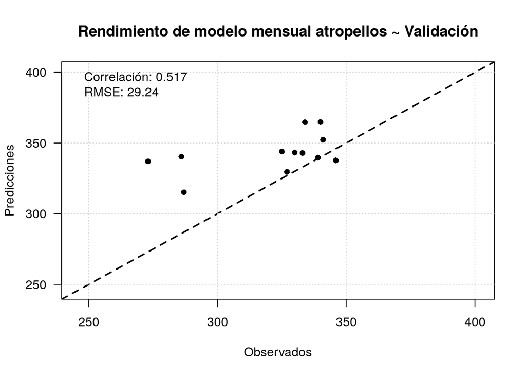

```r
plot_estimation_errors(
  y_true = exp(lasso.atropello.results$validation$response),
  y_pred = exp(lasso.atropello.results$validation$predictions),
  title="Rendimiento de modelo mensual atropellos ~ Validación"
  )
```

```r
test_train_ratio <- round((lasso.atropello.results$validation$rmse / lasso.atropello.results$training$rmse - 1)*100,3)
```

Para el modelo de atropellos, se maneja una variación del RMSE de 20.618%, Pero viendo las gráficas de predicción, puede haber un signo de subajuste de los modelos.

## Caida ocupante

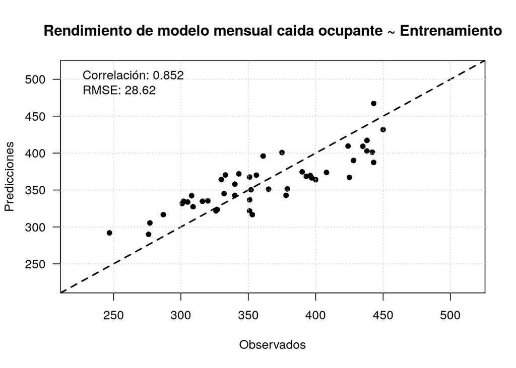

```r
data.caida <- prepare_data(df=df, objective_var = "caida ocupante")
df_caida_train <- data.caida$training
df_caida_test <- data.caida$validation

lasso.caida.results <- train_lasso_model(df_train = df_caida_train, df_test = df_caida_test)


plot_estimation_errors(
  y_true = exp(lasso.caida.results$training$response),
  y_pred = exp(lasso.caida.results$training$predictions),
  title="Rendimiento de modelo mensual caida ocupante ~ Entrenamiento"
  )
```

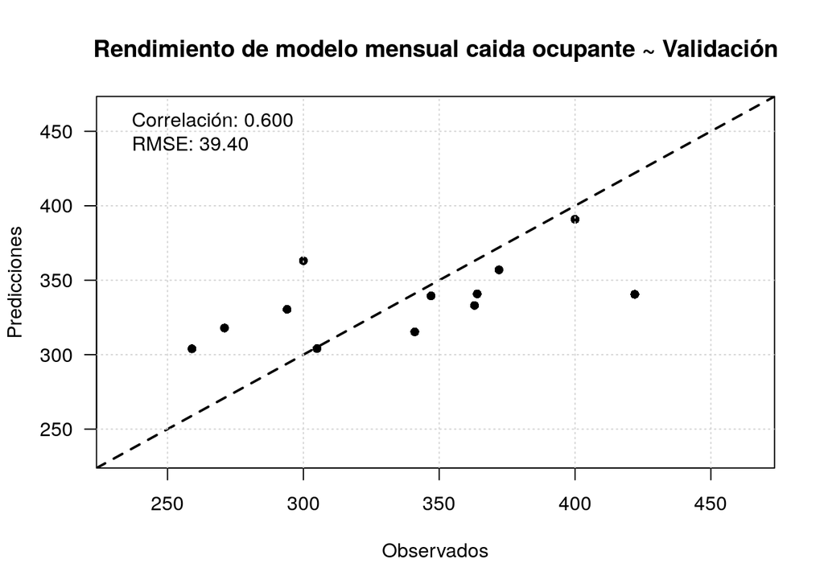

```r
plot_estimation_errors(
  y_true = exp(lasso.caida.results$validation$response),
  y_pred = exp(lasso.caida.results$validation$predictions),
  title="Rendimiento de modelo mensual caida ocupante ~ Validación"
  )
```

```r
test_train_ratio <- round((lasso.caida.results$validation$rmse / lasso.caida.results$training$rmse - 1)*100,3)
```

Para el modelo de caida de ocpante, se maneja una variación del RMSE de 37.677%.

## Volcamiento

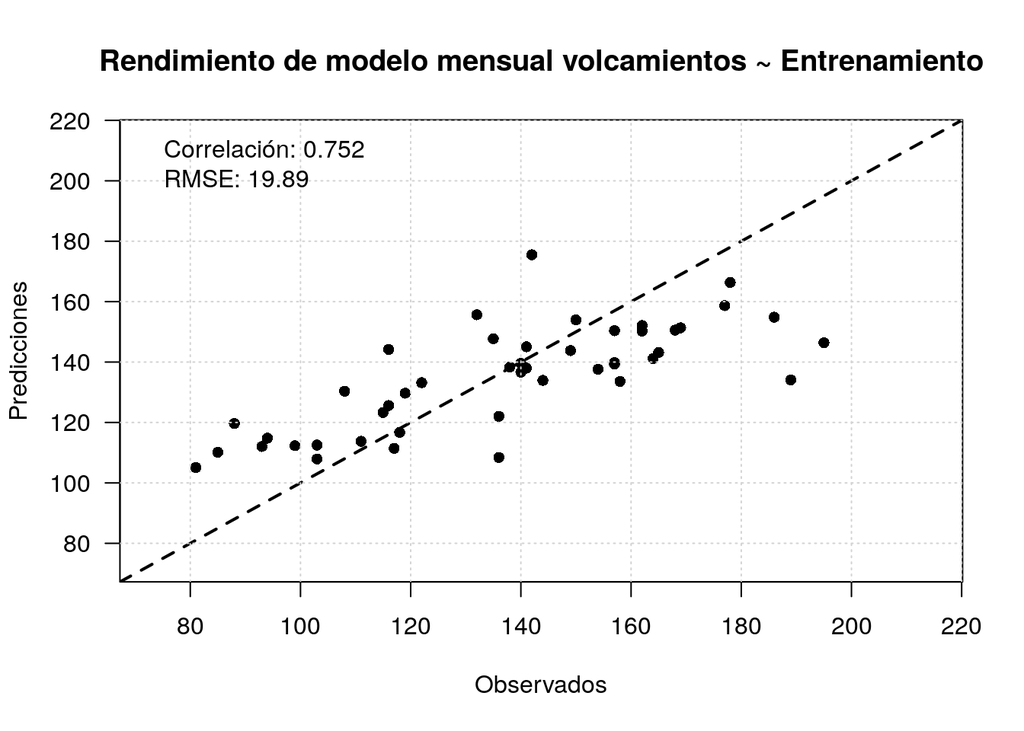

```r
data.volcamiento <- prepare_data(df=df, objective_var = "volcamiento")
df_volcamiento_train <- data.volcamiento$training
df_volcamiento_test <- data.volcamiento$validation

lasso.volcamiento.results <- train_lasso_model(df_train = df_volcamiento_train, df_test = df_volcamiento_test, min_lambda = -3)

plot_estimation_errors(
  y_true = exp(lasso.volcamiento.results$training$response),
  y_pred = exp(lasso.volcamiento.results$training$predictions),
  title="Rendimiento de modelo mensual volcamientos ~ Entrenamiento"
  )
```

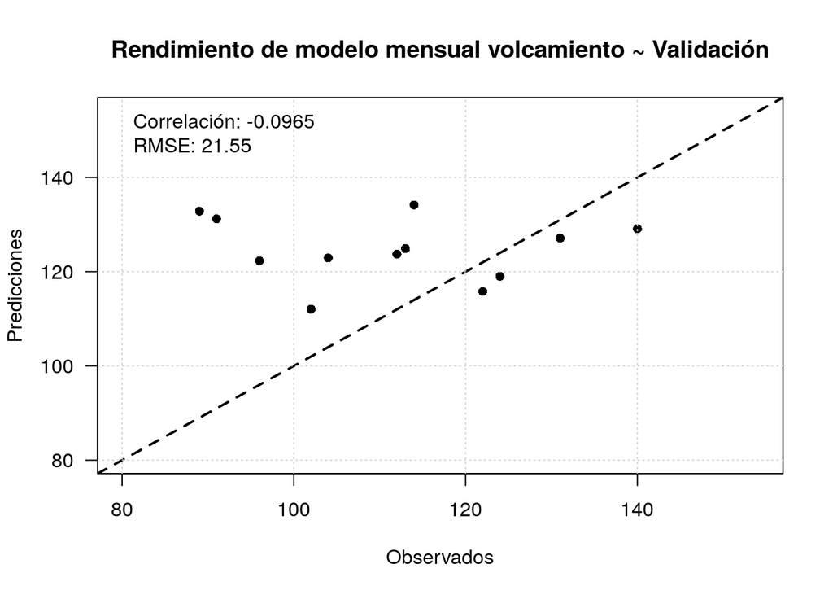

```r
plot_estimation_errors(
  y_true = exp(lasso.volcamiento.results$validation$response),
  y_pred = exp(lasso.volcamiento.results$validation$predictions),
  title="Rendimiento de modelo mensual volcamiento ~ Validación"
  )
```

```r
test_train_ratio <- round((lasso.volcamiento.results$validation$rmse / lasso.volcamiento.results$training$rmse - 1)*100,3)
```

Claramente para el modelo mensual de volcamiento, no se tiene una buena estimación del modelo, ya que aunque se tenga una variación del 8.366%, los errores del modelo con la data de entrenamiento claramente muestran una subestimación del modelo.

## Otros e incendios

Ya que unicamente se tienen 29 registros de incendios, no se tiene la suficiente información para hacer una estimación mensual, por lo que se procedera a realizar una estimación con la clase de **otros**.

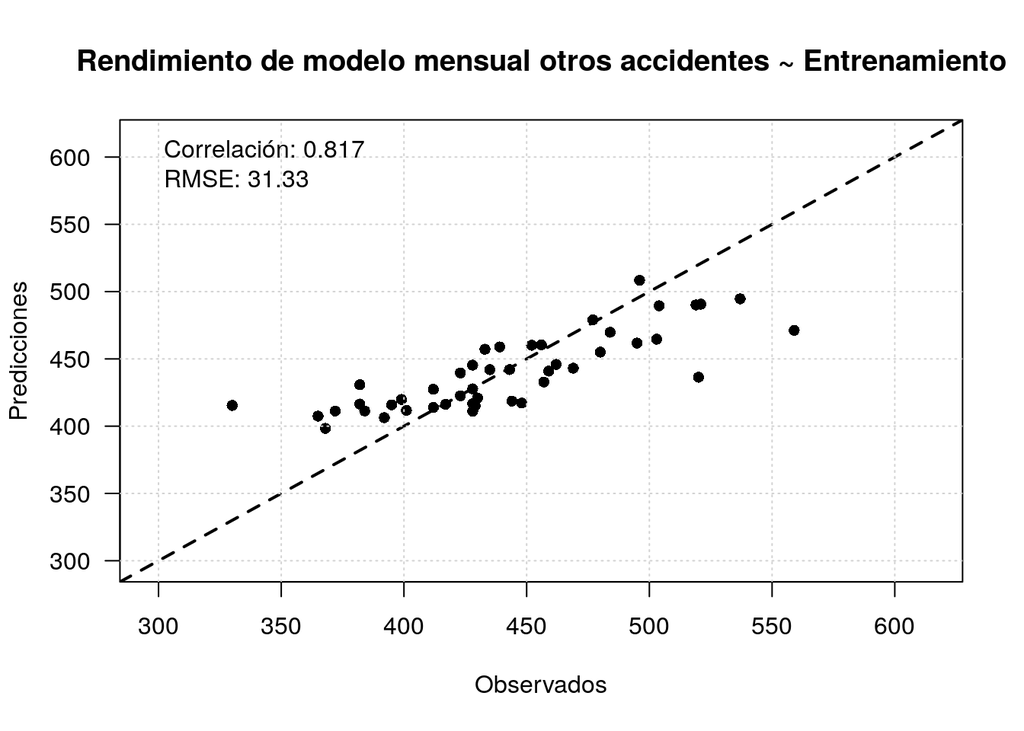

```r
data.otros <- prepare_data(df=df, objective_var =  "otro")
df_otros_train <- data.otros$training
df_otros_test <- data.otros$validation

lasso.otros.results <- train_lasso_model(df_train = df_otros_train, df_test = df_otros_test, min_lambda = -3)

plot_estimation_errors(
  y_true = exp(lasso.otros.results$training$response),
  y_pred = exp(lasso.otros.results$training$predictions),
  title="Rendimiento de modelo mensual otros accidentes ~ Entrenamiento"
  )
```

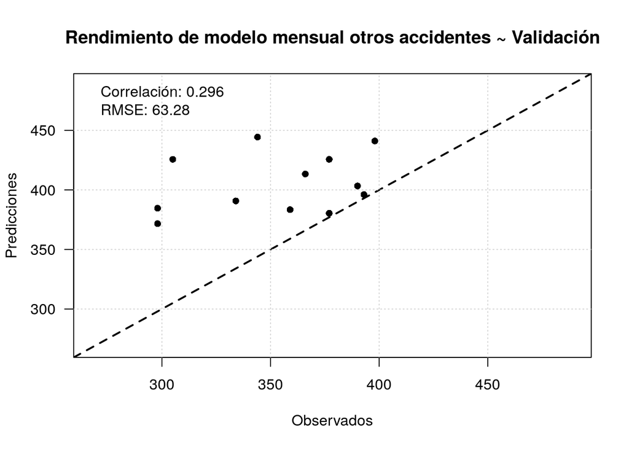

```r
plot_estimation_errors(
  y_true = exp(lasso.otros.results$validation$response),
  y_pred = exp(lasso.otros.results$validation$predictions),
  title="Rendimiento de modelo mensual otros accidentes ~ Validación"
  )
```

```r
test_train_ratio <- round((lasso.otros.results$validation$rmse / lasso.otros.results$training$rmse - 1)*100,3)
```

Se puede evidenciar que el modelo para otro tipo de accidentes tiene una sobreestimación sustancial cuando se le compara contra los valores reales, tal que el RMSE aumenta a casi el doble y no muestra alta correlación entre las observaciones y las predicciones.

## Conclusiones

De los modelos mensuales, se tiene una gran desventaja y es la poca cantidad de observaciones disponibles para hacer unas estimaciones más robustas. Es claro que hay margén de mejora, en especial para los modelos de volcamientos y otros accidentes que fueron los que presentaron el peor error de estimación, proximamente se procedera a explorar otras alternativas de modelamiento para estas clases de accidentes.